# R Notebook

Rioba Ian

## student id: 00482309

# Assignment 1

# Question 1

```r
data = read.csv("/home/rioba/Documents/Mogrey/work6/thanksgiving_meals.csv")

library(tidyverse)
library(skimr)

knitr::kable(head(data), 'pipe')
```

| id | celebrate | main_dish | main_dish_other | main_prep | main_prep_other | stuffing | stuffing_other | cranberry | cranberry_other | gravy | side1 | side2 | side3 | side4 | side5 | side6 | side7 | side8 | side9 | side10 | side11 | side12 | side13 | side14 | side15 | pie1 | pie2 | pie3 | pie4 | … |
| --- | --- | --- | --- | --- | --- | --- | --- | --- | --- | --- | --- | --- | --- | --- | --- | --- | --- | --- | --- | --- | --- | --- | --- | --- | --- | --- | --- | --- | --- | --- |
| 4337954960 | Yes | Turkey | NA | Baked | NA | Bread-based | NA | None | NA | Yes | NA | Carrots | NA | NA | NA | NA | Green beans/green bean casserole | Macaroni and cheese | Mashed potatoes | NA | NA | NA | Yams/sweet potato casserole | NA | NA | Apple | NA | NA | NA | … |
| 4337951949 | Yes | Turkey | NA | Baked | NA | Bread-based | NA | Other (please specify) | Homemade cranberry gelatin ring | Yes | NA | NA | NA | Corn | NA | NA | Green beans/green bean casserole | Macaroni and cheese | Mashed potatoes | Rolls/biscuits | NA | Vegetable salad | Yams/sweet potato casserole | Other (please specify) | Asian vinagrette salad | Apple | NA | NA | Chocolate | … |
| 4337935621 | Yes | Turkey | NA | Roasted | NA | Rice-based | NA | Homemade | NA | Yes | Brussel sprouts | Carrots | Cauliflower | Corn | Cornbread | NA | NA | NA | Mashed potatoes | Rolls/biscuits | NA | Vegetable salad | NA | NA | NA | Apple | NA | Cherry | NA | … |
| 4337933040 | Yes | Turkey | NA | Baked | NA | Bread-based | NA | Homemade | NA | Yes | Brussel sprouts | NA | NA | NA | Cornbread | NA | NA | NA | Mashed potatoes | Rolls/biscuits | NA | Vegetable salad | Yams/sweet potato casserole | NA | NA | NA | NA | NA | NA | … |
| 4337931983 | Yes | Tofurkey | NA | Baked | NA | Bread-based | NA | Canned | NA | Yes | Brussel sprouts | NA | NA | NA | Cornbread | NA | NA | NA | Mashed potatoes | Rolls/biscuits | Squash | Vegetable salad | Yams/sweet potato casserole | NA | NA | Apple | NA | NA | NA | … |
| 4337929779 | Yes | Turkey | NA | Roasted | NA | Rice-based | NA | Homemade | NA | Yes | Brussel sprouts | Carrots | Cauliflower | Corn | Cornbread | Fruit salad | Green beans/green bean casserole | Macaroni and cheese | Mashed potatoes | Rolls/biscuits | Squash | Vegetable salad | Yams/sweet potato casserole | NA | NA | NA | NA | NA | NA | … |

# Question 2

We shall use the `skim()` to display the summary in a table.

```r
knitr::kable(skim(data))
```

| skim_type | skim_variable | n_missing | complete_rate | character.min | character.max | character.empty | character.n_unique | character.whitespace | numeric.mean | numeric.sd | numeric.p0 | numeric.p25 | numeric.p50 | numeric.p75 | numeric.p100 | numeric.hist |
| --- | --- | --- | --- | --- | --- | --- | --- | --- | --- | --- | --- | --- | --- | --- | --- | --- |
| character | celebrate | 0 | 1.0000000 | 2 | 3 | 0 | 2 | 0 | NA | NA | NA | NA | NA | NA | NA | NA |
| character | main_dish | 84 | 0.9206049 | 6 | 22 | 0 | 8 | 0 | NA | NA | NA | NA | NA | NA | NA | NA |
| character | main_dish_other | 1023 | 0.0330813 | 4 | 85 | 0 | 32 | 0 | NA | NA | NA | NA | NA | NA | NA | NA |
| character | main_prep | 84 | 0.9206049 | 5 | 22 | 0 | 5 | 0 | NA | NA | NA | NA | NA | NA | NA | NA |
| character | main_prep_other | 1007 | 0.0482042 | 1 | 33 | 0 | 32 | 0 | NA | NA | NA | NA | NA | NA | NA | NA |
| character | stuffing | 84 | 0.9206049 | 4 | 22 | 0 | 4 | 0 | NA | NA | NA | NA | NA | NA | NA | NA |
| character | stuffing_other | 1022 | 0.0340265 | 4 | 46 | 0 | 29 | 0 | NA | NA | NA | NA | NA | NA | NA | NA |
| character | cranberry | 84 | 0.9206049 | 4 | 22 | 0 | 4 | 0 | NA | NA | NA | NA | NA | NA | NA | NA |
| character | cranberry_other | 1033 | 0.0236295 | 3 | 61 | 0 | 24 | 0 | NA | NA | NA | NA | NA | NA | NA | NA |
| character | gravy | 84 | 0.9206049 | 2 | 3 | 0 | 2 | 0 | NA | NA | NA | NA | NA | NA | NA | NA |
| character | side1 | 903 | 0.1465028 | 15 | 15 | 0 | 1 | 0 | NA | NA | NA | NA | NA | NA | NA | NA |
| character | side2 | 816 | 0.2287335 | 7 | 7 | 0 | 1 | 0 | NA | NA | NA | NA | NA | NA | NA | NA |
| character | side3 | 970 | 0.0831758 | 11 | 11 | 0 | 1 | 0 | NA | NA | NA | NA | NA | NA | NA | NA |
| character | side4 | 594 | 0.4385633 | 4 | 4 | 0 | 1 | 0 | NA | NA | NA | NA | NA | NA | NA | NA |
| character | side5 | 823 | 0.2221172 | 9 | 9 | 0 | 1 | 0 | NA | NA | NA | NA | NA | NA | NA | NA |
| character | side6 | 843 | 0.2032136 | 11 | 11 | 0 | 1 | 0 | NA | NA | NA | NA | NA | NA | NA | NA |
| character | side7 | 372 | 0.6483932 | 32 | 32 | 0 | 1 | 0 | NA | NA | NA | NA | NA | NA | NA | NA |
| character | side8 | 852 | 0.1947070 | 19 | 19 | 0 | 1 | 0 | NA | NA | NA | NA | NA | NA | NA | NA |
| character | side9 | 241 | 0.7722117 | 15 | 15 | 0 | 1 | 0 | NA | NA | NA | NA | NA | NA | NA | NA |
| character | side10 | 292 | 0.7240076 | 14 | 14 | 0 | 1 | 0 | NA | NA | NA | NA | NA | NA | NA | NA |
| character | side11 | 887 | 0.1616257 | 6 | 6 | 0 | 1 | 0 | NA | NA | NA | NA | NA | NA | NA | NA |
| character | side12 | 849 | 0.1975425 | 15 | 15 | 0 | 1 | 0 | NA | NA | NA | NA | NA | NA | NA | NA |
| character | side13 | 427 | 0.5964083 | 27 | 27 | 0 | 1 | 0 | NA | NA | NA | NA | NA | NA | NA | NA |
| character | side14 | 947 | 0.1049149 | 22 | 22 | 0 | 1 | 0 | NA | NA | NA | NA | NA | NA | NA | NA |
| character | side15 | 947 | 0.1049149 | 4 | 78 | 0 | 89 | 0 | NA | NA | NA | NA | NA | NA | NA | NA |
| character | pie1 | 544 | 0.4858223 | 5 | 5 | 0 | 1 | 0 | NA | NA | NA | NA | NA | NA | NA | NA |
| character | pie2 | 1023 | 0.0330813 | 10 | 10 | 0 | 1 | 0 | NA | NA | NA | NA | NA | NA | NA | NA |
| character | pie3 | 945 | 0.1068053 | 6 | 6 | 0 | 1 | 0 | NA | NA | NA | NA | NA | NA | NA | NA |
| character | pie4 | 925 | 0.1257089 | 9 | 9 | 0 | 1 | 0 | NA | NA | NA | NA | NA | NA | NA | NA |
| character | pie5 | 1022 | 0.0340265 | 13 | 13 | 0 | 1 | 0 | NA | NA | NA | NA | NA | NA | NA | NA |
| character | pie6 | 1019 | 0.0368620 | 8 | 8 | 0 | 1 | 0 | NA | NA | NA | NA | NA | NA | NA | NA |
| character | pie7 | 1024 | 0.0321361 | 5 | 5 | 0 | 1 | 0 | NA | NA | NA | NA | NA | NA | NA | NA |
| character | pie8 | 716 | 0.3232514 | 5 | 5 | 0 | 1 | 0 | NA | NA | NA | NA | NA | NA | NA | NA |
| character | pie9 | 329 | 0.6890359 | 7 | 7 | 0 | 1 | 0 | NA | NA | NA | NA | NA | NA | NA | NA |
| character | pie10 | 906 | 0.1436673 | 12 | 12 | 0 | 1 | 0 | NA | NA | NA | NA | NA | NA | NA | NA |
| character | pie11 | 1018 | 0.0378072 | 4 | 4 | 0 | 1 | 0 | NA | NA | NA | NA | NA | NA | NA | NA |
| character | pie12 | 987 | 0.0671078 | 22 | 22 | 0 | 1 | 0 | NA | NA | NA | NA | NA | NA | NA | NA |
| character | pie13 | 987 | 0.0671078 | 5 | 46 | 0 | 61 | 0 | NA | NA | NA | NA | NA | NA | NA | NA |
| character | dessert1 | 948 | 0.1039698 | 13 | 13 | 0 | 1 | 0 | NA | NA | NA | NA | NA | NA | NA | NA |
| character | dessert2 | 1042 | 0.0151229 | 8 | 8 | 0 | 1 | 0 | NA | NA | NA | NA | NA | NA | NA | NA |
| character | dessert3 | 930 | 0.1209830 | 8 | 8 | 0 | 1 | 0 | NA | NA | NA | NA | NA | NA | NA | NA |
| character | dessert4 | 986 | 0.0680529 | 11 | 11 | 0 | 1 | 0 | NA | NA | NA | NA | NA | NA | NA | NA |
| character | dessert5 | 867 | 0.1805293 | 10 | 10 | 0 | 1 | 0 | NA | NA | NA | NA | NA | NA | NA | NA |
| character | dessert6 | 854 | 0.1928166 | 7 | 7 | 0 | 1 | 0 | NA | NA | NA | NA | NA | NA | NA | NA |
| character | dessert7 | 1015 | 0.0406427 | 5 | 5 | 0 | 1 | 0 | NA | NA | NA | NA | NA | NA | NA | NA |
| character | dessert8 | 792 | 0.2514178 | 9 | 9 | 0 | 1 | 0 | NA | NA | NA | NA | NA | NA | NA | NA |
| character | dessert9 | 955 | 0.0973535 | 13 | 13 | 0 | 1 | 0 | NA | NA | NA | NA | NA | NA | NA | NA |
| character | dessert10 | 763 | 0.2788280 | 4 | 4 | 0 | 1 | 0 | NA | NA | NA | NA | NA | NA | NA | NA |
| character | dessert11 | 924 | 0.1266541 | 22 | 22 | 0 | 1 | 0 | NA | NA | NA | NA | NA | NA | NA | NA |
| character | dessert12 | 924 | 0.1266541 | 3 | 59 | 0 | 92 | 0 | NA | NA | NA | NA | NA | NA | NA | NA |
| character | prayer | 99 | 0.9064272 | 2 | 3 | 0 | 2 | 0 | NA | NA | NA | NA | NA | NA | NA | NA |
| character | travel | 107 | 0.8988658 | 59 | 80 | 0 | 4 | 0 | NA | NA | NA | NA | NA | NA | NA | NA |
| character | watch_program | 556 | 0.4744802 | 13 | 13 | 0 | 1 | 0 | NA | NA | NA | NA | NA | NA | NA | NA |
| character | kids_table_age | 107 | 0.8988658 | 2 | 13 | 0 | 12 | 0 | NA | NA | NA | NA | NA | NA | NA | NA |
| character | hometown_friends | 107 | 0.8988658 | 2 | 3 | 0 | 2 | 0 | NA | NA | NA | NA | NA | NA | NA | NA |
| character | friendsgiving | 107 | 0.8988658 | 2 | 3 | 0 | 2 | 0 | NA | NA | NA | NA | NA | NA | NA | NA |
| character | black_friday | 107 | 0.8988658 | 2 | 3 | 0 | 2 | 0 | NA | NA | NA | NA | NA | NA | NA | NA |
| character | work_retail | 107 | 0.8988658 | 2 | 3 | 0 | 2 | 0 | NA | NA | NA | NA | NA | NA | NA | NA |
| character | work_black_friday | 988 | 0.0661626 | 2 | 13 | 0 | 3 | 0 | NA | NA | NA | NA | NA | NA | NA | NA |
| character | community_type | 110 | 0.8960302 | 5 | 8 | 0 | 3 | 0 | NA | NA | NA | NA | NA | NA | NA | NA |
| character | age | 33 | 0.9688091 | 3 | 7 | 0 | 4 | 0 | NA | NA | NA | NA | NA | NA | NA | NA |
| character | gender | 33 | 0.9688091 | 4 | 6 | 0 | 2 | 0 | NA | NA | NA | NA | NA | NA | NA | NA |
| character | family_income | 33 | 0.9688091 | 12 | 20 | 0 | 11 | 0 | NA | NA | NA | NA | NA | NA | NA | NA |
| character | us_region | 59 | 0.9442344 | 7 | 18 | 0 | 9 | 0 | NA | NA | NA | NA | NA | NA | NA | NA |
| numeric | id | 0 | 1.0000000 | NA | NA | NA | NA | NA | 4336731188 | 493783.4 | 4335894916 | 4336339486 | 4336796628 | 4337012140 | 4337954960 | ▅▃▇▂▂ |

# Question 3

In this question we are supposed to think of a the variables in the dataset that maybe useful to predict the family income and if they are in the correct format.  
The variables that could be useful in predicting the family income are the gender, age, community type, working in retail, attended a friend giving, meeting up with home-town friends, cut off age at thanksgiving for the kids and celebrating. The community type variable could affect income as it gives the kind of neighborhood that the parents live in. If one has ever attended a friends giving and meeting up with hometown friends could be indicators of family income because families will tend to have a higher income from being helped with their friends and community.

- Do you celebrate Thanksgiving?
- What is typically the main dish at your Thanksgiving dinner?
- How is the main dish typically cooked?
- What kind of stuffing/dressing do you typically have?
- What type of cranberry sauce do you typically have?
- Do you typically have gravy?
- Which of these side dishes are typically served at your Thanksgiving dinner?
- Which type of pie is typically served at your Thanksgiving dinner?
- Which of these desserts do you typically have at Thanksgiving dinner?

```r
knitr::kable(data %>%
  count(us_region))
```

| us_region | n |
| --- | --- |
| East North Central | 150 |
| East South Central | 60 |
| Middle Atlantic | 159 |
| Mountain | 47 |
| New England | 58 |
| Pacific | 146 |
| South Atlantic | 214 |
| West North Central | 74 |
| West South Central | 91 |
| NA | 59 |

```r
knitr::kable(data %>%
  count(main_dish, main_prep, sort = TRUE))
```

| main_dish | main_prep | n |
| --- | --- | --- |
| Turkey | Baked | 422 |
| Turkey | Roasted | 351 |
| NA | NA | 84 |
| Turkey | Fried | 41 |
| Turkey | Other (please specify) | 34 |
| Ham/Pork | Baked | 22 |
| Other (please specify) | Baked | 16 |
| Tofurkey | Baked | 14 |
| Other (please specify) | Other (please specify) | 12 |
| Turkey | I don’t know | 11 |
| Ham/Pork | Roasted | 5 |
| Other (please specify) | Roasted | 5 |
| Roast beef | Roasted | 5 |
| Chicken | Baked | 4 |
| Chicken | Roasted | 4 |
| Tofurkey | Roasted | 4 |
| I don’t know | I don’t know | 3 |
| Roast beef | Baked | 3 |
| Turducken | Roasted | 3 |
| Chicken | Fried | 2 |
| Chicken | Other (please specify) | 2 |
| Roast beef | Fried | 2 |
| Ham/Pork | I don’t know | 1 |
| Ham/Pork | Other (please specify) | 1 |
| I don’t know | Fried | 1 |
| I don’t know | Roasted | 1 |
| Other (please specify) | Fried | 1 |
| Other (please specify) | I don’t know | 1 |
| Roast beef | Other (please specify) | 1 |
| Tofurkey | I don’t know | 1 |
| Tofurkey | Other (please specify) | 1 |

```r
knitr::kable(data %>%
  mutate(family_income = fct_reorder(family_income, parse_number(family_income))) %>%
  count(family_income))
```

| family_income | n |
| --- | --- |
| $0 to $9,999 | 66 |
| $10,000 to $24,999 | 68 |
| $25,000 to $49,999 | 180 |
| $50,000 to $74,999 | 135 |
| $75,000 to $99,999 | 133 |
| $100,000 to $124,999 | 111 |
| $125,000 to $149,999 | 49 |
| $150,000 to $174,999 | 40 |
| $175,000 to $199,999 | 27 |
| $200,000 and up | 80 |
| Prefer not to answer | 136 |
| NA | 33 |

# Question 3

We have used the fct_reorder and the parse function to compute the family income. We can now group by the family income.

```r
family_income_df = read.csv("/home/rioba/Documents/Mogrey/work6/thanksgiving_meals.csv")%>%
  mutate(family_income = fct_reorder(family_income,parse_number(family_income)))
knitr::kable(family_income_df%>%group_by(family_income)%>%
summarize(homemade = mean(cranberry == "Homemade"),
          size = n()))
```

| family_income | homemade | size |
| --- | --- | --- |
| $0 to $9,999 | NA | 66 |
| $10,000 to $24,999 | NA | 68 |
| $25,000 to $49,999 | NA | 180 |
| $50,000 to $74,999 | NA | 135 |
| $75,000 to $99,999 | NA | 133 |
| $100,000 to $124,999 | NA | 111 |
| $125,000 to $149,999 | NA | 49 |
| $150,000 to $174,999 | NA | 40 |
| $175,000 to $199,999 | NA | 27 |
| $200,000 and up | NA | 80 |
| Prefer not to answer | NA | 136 |
| NA | NA | 33 |

#Question 4 Those who celebrate and those who don’t celebrate

```r
# Those who celebrate are 980.
knitr::kable(data %>%
  count(celebrate))
```

| celebrate | n |
| --- | --- |
| No | 78 |
| Yes | 980 |

#Question 5

```r
library(curl)
dim(data)
```

```
## [1] 1058   65
```

[figure not shown]

```r
#colnames(data)

#susetting data
ggplot(data, mapping = aes(data$us_region))+
    geom_bar(aes(fill=data$age))+
    xlab('Living Region')+labs(fill='gender')+geom_text(stat='count',aes(label = ..count..,y=..count..),vjust=-0.2)+
    ggtitle('Poll data')
```

more visualizations

[figure not shown]

```r
ggplot(data, mapping = aes(data$us_region))+
    geom_bar(aes(fill=data$celebrate))+
    xlab('US Region')+labs(fill='age_range')+geom_text(stat='count',aes(label = ..count..,y=..count..),vjust=-0.2)+
    theme(axis.text.x = element_text(angle = 90))+
    ggtitle('Poll data')
```

## Question 7

Those who use cranberry sauce and grovy

```r
knitr::kable(family_income_df%>%group_by(family_income)%>%
summarize(gravy_sauce = mean(gravy),
          size = n()))
```

| family_income | gravy_sauce | size |
| --- | --- | --- |
| $0 to $9,999 | NA | 66 |
| $10,000 to $24,999 | NA | 68 |
| $25,000 to $49,999 | NA | 180 |
| $50,000 to $74,999 | NA | 135 |
| $75,000 to $99,999 | NA | 133 |
| $100,000 to $124,999 | NA | 111 |
| $125,000 to $149,999 | NA | 49 |
| $150,000 to $174,999 | NA | 40 |
| $175,000 to $199,999 | NA | 27 |
| $200,000 and up | NA | 80 |
| Prefer not to answer | NA | 136 |
| NA | NA | 33 |

## Analysing the dessert and food.

```r
food_gathered = family_income_df%>%
  select(id, starts_with("side"),
         starts_with("pie"),
         starts_with("dessert")) %>%
  select(-side15, -pie13,-dessert12)%>%
    gather(type, value, -id) %>%
    filter(!is.na(value)) %>%
    mutate(type= str_remove(type, "\\d+"))

food_gathered%>%
  count(type, value, sort = TRUE)
```

| type | value | n |
| --- | --- | --- |
| side | Mashed potatoes | 817 |
| side | Rolls/biscuits | 766 |
| pie | Pumpkin | 729 |
| side | Green beans/green bean casserole | 686 |
| side | Yams/sweet potato casserole | 631 |
| pie | Apple | 514 |
| side | Corn | 464 |
| pie | Pecan | 342 |
| dessert | None | 295 |
| dessert | Ice cream | 266 |

[output cut: 27 more lines]

## Question 10

We could ask ourselves a question of what are people actually eating.

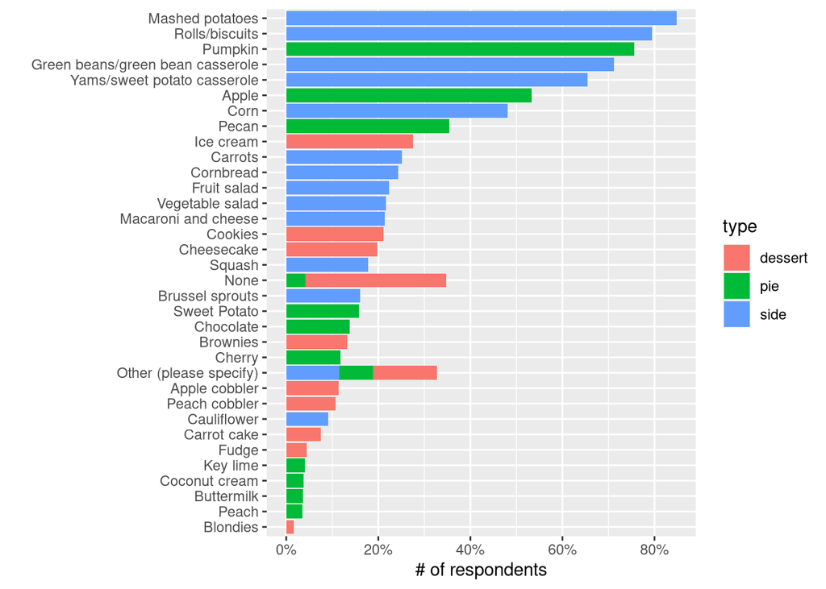

```r
n_respondents = n_distinct(food_gathered$id)

food_gathered%>%
  count(type, value, sort = TRUE)%>%
  mutate(value = fct_reorder(value, n))%>%
  ggplot(aes(value, n/n_respondents, fill=type))+
  geom_col()+
  coord_flip()+
  scale_y_continuous(labels = scales::percent_format()) +
  labs(x="",
       y="# of respondents")
```

what are the most common pies, sides and desserts?

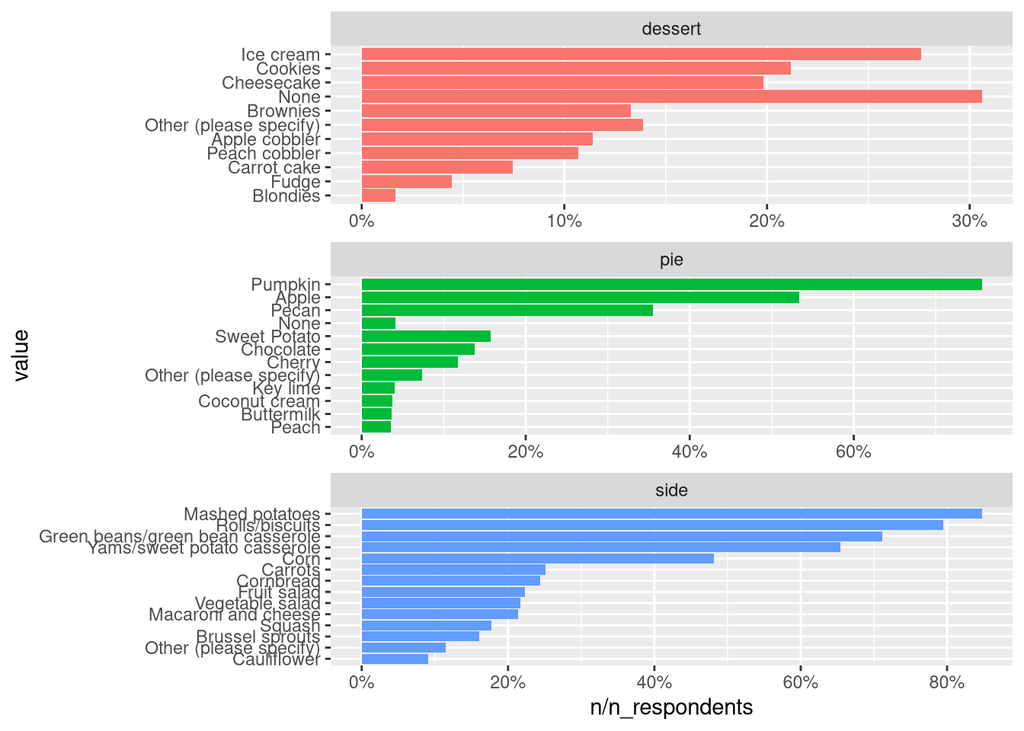

```r
food_gathered%>%
  count(type, value, sort = TRUE)%>%
  mutate(value = fct_reorder(value, n))%>%
  ggplot(aes(value, n/n_respondents, fill=type))+
  geom_col(show.legend = FALSE)+
  coord_flip()+
  scale_y_continuous(labels = scales::percent_format()) +
  facet_wrap(~ type, scales = "free", ncol=1)
```

```r
  labs(x="",
       y="# of respondents")
```

```
## $x
## [1] ""
##
## $y
## [1] "# of respondents"
##
## attr(,"class")
## [1] "labels"
```

```r
food_gathered%>%
  inner_join(family_income_df, by="id")%>%
  mutate(age_number = parse_number(age))%>%
  group_by(value) %>%
  summarize(average_age = mean(age_number, na.rm = TRUE), total = n()) %>%
  arrange(desc(average_age))
```

| value | average_age | total |
| --- | --- | --- |
| None | 42.46224 | 335 |
| Other (please specify) | 41.89355 | 316 |
| Fruit salad | 41.25359 | 215 |
| Yams/sweet potato casserole | 41.16000 | 631 |
| Coconut cream | 41.11765 | 36 |
| Squash | 40.46429 | 171 |
| Vegetable salad | 40.40394 | 209 |
| Pecan | 39.94690 | 342 |
| Apple | 39.77210 | 514 |
| Mashed potatoes | 39.76398 | 817 |

[output cut: 24 more lines]

The count of the regions and their respondents

```r
food_by_region = food_gathered%>%
  inner_join(family_income_df, by="id")%>%
  group_by(us_region)%>%
  mutate(respondents = n_distinct(id))%>%
  count(us_region, respondents, type,value) %>%
  ungroup()%>%
  mutate(percent = n/respondents)

food_by_region%>%
  filter(value == "Apple")
```

| us_region | respondents | type | value | n | percent |
| --- | --- | --- | --- | --- | --- |
| East North Central | 145 | pie | Apple | 75 | 0.5172414 |
| East South Central | 56 | pie | Apple | 19 | 0.3392857 |
| Middle Atlantic | 145 | pie | Apple | 106 | 0.7310345 |
| Mountain | 41 | pie | Apple | 19 | 0.4634146 |
| New England | 55 | pie | Apple | 41 | 0.7454545 |
| Pacific | 130 | pie | Apple | 74 | 0.5692308 |
| South Atlantic | 203 | pie | Apple | 101 | 0.4975369 |
| West North Central | 71 | pie | Apple | 37 | 0.5211268 |
| West South Central | 85 | pie | Apple | 32 | 0.3764706 |
| NA | 33 | pie | Apple | 10 | 0.3030303 |

```r
food_by_region%>%
  filter(value == "Apple") %>%
  arrange(desc(percent))
```

| us_region | respondents | type | value | n | percent |
| --- | --- | --- | --- | --- | --- |
| New England | 55 | pie | Apple | 41 | 0.7454545 |
| Middle Atlantic | 145 | pie | Apple | 106 | 0.7310345 |
| Pacific | 130 | pie | Apple | 74 | 0.5692308 |
| West North Central | 71 | pie | Apple | 37 | 0.5211268 |
| East North Central | 145 | pie | Apple | 75 | 0.5172414 |
| South Atlantic | 203 | pie | Apple | 101 | 0.4975369 |
| Mountain | 41 | pie | Apple | 19 | 0.4634146 |
| West South Central | 85 | pie | Apple | 32 | 0.3764706 |
| East South Central | 56 | pie | Apple | 19 | 0.3392857 |
| NA | 33 | pie | Apple | 10 | 0.3030303 |

```r
food_by_region%>%
  filter(value == "Pumpkin") %>%
  arrange(desc(percent))
```

| us_region | respondents | type | value | n | percent |
| --- | --- | --- | --- | --- | --- |
| New England | 55 | pie | Pumpkin | 46 | 0.8363636 |
| Mountain | 41 | pie | Pumpkin | 34 | 0.8292683 |
| Pacific | 130 | pie | Pumpkin | 105 | 0.8076923 |
| West North Central | 71 | pie | Pumpkin | 57 | 0.8028169 |
| West South Central | 85 | pie | Pumpkin | 68 | 0.8000000 |
| Middle Atlantic | 145 | pie | Pumpkin | 115 | 0.7931034 |
| East North Central | 145 | pie | Pumpkin | 113 | 0.7793103 |
| East South Central | 56 | pie | Pumpkin | 38 | 0.6785714 |
| South Atlantic | 203 | pie | Pumpkin | 135 | 0.6650246 |
| NA | 33 | pie | Pumpkin | 18 | 0.5454545 |

```r
food_by_region%>%
  filter(value == "Cornbread") %>%
  arrange(desc(percent))
```

| us_region | respondents | type | value | n | percent |
| --- | --- | --- | --- | --- | --- |
| West South Central | 85 | side | Cornbread | 34 | 0.4000000 |
| East South Central | 56 | side | Cornbread | 16 | 0.2857143 |
| Pacific | 130 | side | Cornbread | 37 | 0.2846154 |
| South Atlantic | 203 | side | Cornbread | 53 | 0.2610837 |
| Mountain | 41 | side | Cornbread | 10 | 0.2439024 |
| Middle Atlantic | 145 | side | Cornbread | 33 | 0.2275862 |
| NA | 33 | side | Cornbread | 7 | 0.2121212 |
| New England | 55 | side | Cornbread | 10 | 0.1818182 |
| West North Central | 71 | side | Cornbread | 12 | 0.1690141 |
| East North Central | 145 | side | Cornbread | 23 | 0.1586207 |

Did you pray before and after thanksgiving meal?

```r
food_gathered %>%
  inner_join(family_income_df, by="id")%>%
  filter(!is.na(prayer))%>%
  group_by(type, value) %>%
  summarize(prayer = sum(prayer == "Yes"),
            total = n(),
            percent = prayer / total)%>%
  arrange(desc(percent))
```

| type | value | prayer | total | percent |
| --- | --- | --- | --- | --- |
| pie | Coconut cream | 29 | 35 | 0.8285714 |
| side | Macaroni and cheese | 169 | 205 | 0.8243902 |
| pie | Sweet Potato | 121 | 151 | 0.8013245 |
| dessert | Peach cobbler | 81 | 102 | 0.7941176 |
| side | Fruit salad | 169 | 214 | 0.7897196 |
| pie | Cherry | 86 | 112 | 0.7678571 |
| dessert | Cheesecake | 142 | 189 | 0.7513228 |
| dessert | Carrot cake | 54 | 72 | 0.7500000 |
| pie | Buttermilk | 25 | 34 | 0.7352941 |
| dessert | Fudge | 31 | 43 | 0.7209302 |

[output cut: 27 more lines]

Question 11-13

what sides are eaten together?

```r
library(widyr)

food_cors = food_gathered %>%
  pairwise_count(value, id, sort=TRUE)
```

```
## Using `stress` as default layout
```

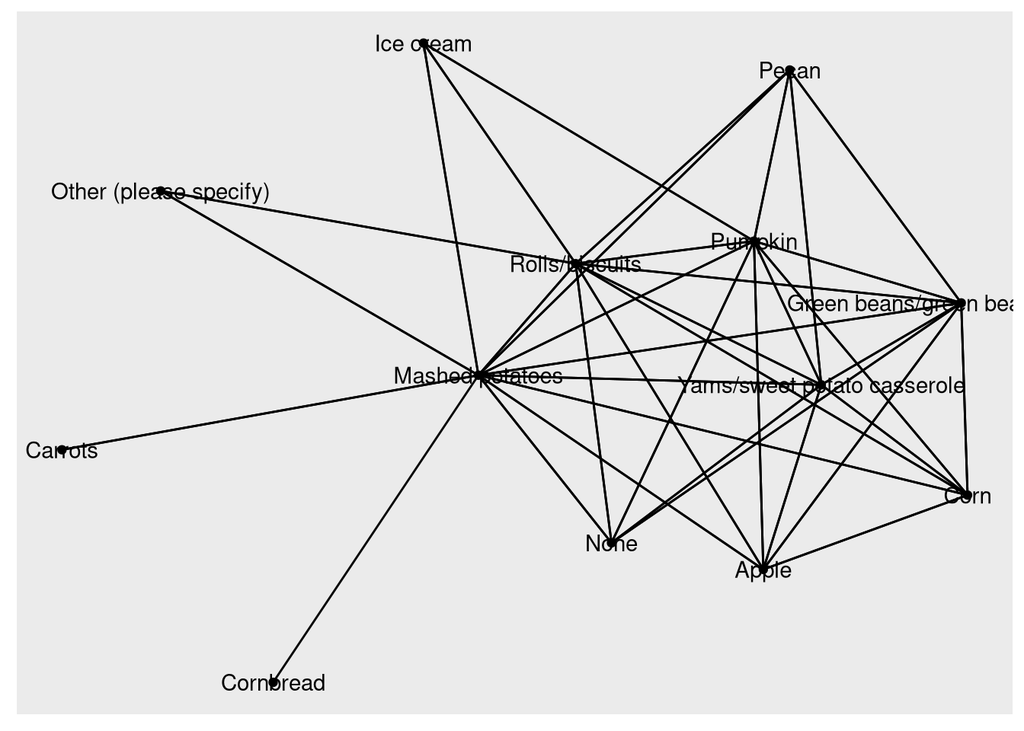

```r
library(ggraph)
library(igraph)
set.seed(234)

food_cors %>%
  head(75) %>%
  graph_from_data_frame()%>%
  ggraph()+
  geom_edge_link()+
  geom_node_point()+
  geom_node_text(aes(label = name))
```

## Running Regression lm()

```r
data_clean = select(data, us_region, gender, age, community_type, work_retail, friendsgiving, hometown_friends, celebrate, family_income)


data_clean$family_income  = parse_number(data_clean$family_income)
data_clean$age = parse_number(data_clean$age)

sum(is.na(data_clean))
```

```
## [1] 725
```

```r
df = na.omit(data_clean)

dim(df)
```

```
## [1] 814   9
```

lm() for the family income based on the us_region, gender, age, community_type, work_retail, friendsgiving, hometown_friends, celebrate, family_income.

```r
lapply(df[c("us_region", "gender"
,"age","community_type","work_retail",      "friendsgiving","hometown_friends","celebrate"  , "family_income")], unique)
```

```
## $us_region
## [1] "Middle Atlantic"    "East South Central" "Mountain"
## [4] "Pacific"            "East North Central" "West North Central"
## [7] "West South Central" "South Atlantic"     "New England"
##
## $gender
## [1] "Male"   "Female"
##
## $age
## [1] 18 30 60 45
##
## $community_type
## [1] "Suburban" "Rural"    "Urban"
##
## $work_retail
## [1] "No"  "Yes"
##
## $friendsgiving
## [1] "No"  "Yes"
##
## $hometown_friends
## [1] "Yes" "No"
##
## $celebrate
## [1] "Yes"
##
## $family_income
##  [1]  75000  50000      0 200000 100000  25000  10000 175000 150000 125000
```

```r
model_regression = lm(family_income ~ us_region+ gender+age+community_type+ work_retail+ friendsgiving+ hometown_friends , data = df )

summary(model_regression)
```

```
##
## Call:
## lm(formula = family_income ~ us_region + gender + age + community_type +
##     work_retail + friendsgiving + hometown_friends, data = df)
##
## Residuals:
##    Min     1Q Median     3Q    Max
## -98181 -43647 -10339  30312 169406
##
## Coefficients:
##                               Estimate Std. Error t value Pr(>|t|)
## (Intercept)                  31740.568   8812.033   3.602 0.000335 ***
## us_regionEast South Central  -4325.978   9193.343  -0.471 0.638087
## us_regionMiddle Atlantic     17386.711   7098.674   2.449 0.014528 *
## us_regionMountain            16317.427  10963.004   1.488 0.137038
## us_regionNew England         14425.839   9827.786   1.468 0.142536
## us_regionPacific              4696.456   7350.499   0.639 0.523052
## us_regionSouth Atlantic      -3622.399   6542.919  -0.554 0.579983
## us_regionWest North Central  -1428.531   8878.116  -0.161 0.872209
## us_regionWest South Central  11113.201   8184.933   1.358 0.174923
## genderMale                    6924.349   4017.208   1.724 0.085154 .
## age                            910.254    136.667   6.660 5.08e-11 ***
## community_typeSuburban        7399.841   5068.020   1.460 0.144655
## community_typeUrban         -10385.248   5968.522  -1.740 0.082244 .
## work_retailYes              -12642.095   7766.709  -1.628 0.103977
## friendsgivingYes                 1.915   4990.194   0.000 0.999694
## hometown_friendsYes           -777.541   4409.749  -0.176 0.860085
## ---
## Signif. codes:  0 '***' 0.001 '**' 0.01 '*' 0.05 '.' 0.1 ' ' 1
##
## Residual standard error: 56340 on 798 degrees of freedom
## Multiple R-squared:  0.1012, Adjusted R-squared:  0.0843
## F-statistic:  5.99 on 15 and 798 DF,  p-value: 5.916e-12
```

Linear regression while removing where they work in retail.

```r
model_regression_retail = lm(family_income ~ us_region+ gender+age+community_type+ friendsgiving+ hometown_friends , data = df )

summary(model_regression_retail)
```

```
##
## Call:
## lm(formula = family_income ~ us_region + gender + age + community_type +
##     friendsgiving + hometown_friends, data = df)
##
## Residuals:
##    Min     1Q Median     3Q    Max
## -98039 -43840 -10744  31674 158636
##
## Coefficients:
##                             Estimate Std. Error t value Pr(>|t|)
## (Intercept)                  30262.2     8774.1   3.449 0.000592 ***
## us_regionEast South Central  -4239.5     9202.7  -0.461 0.645156
## us_regionMiddle Atlantic     16767.9     7095.8   2.363 0.018363 *
## us_regionMountain            16247.2    10974.2   1.480 0.139138
## us_regionNew England         14152.8     9836.5   1.439 0.150598
## us_regionPacific              4672.0     7358.1   0.635 0.525647
## us_regionSouth Atlantic      -4153.4     6541.5  -0.635 0.525654
## us_regionWest North Central  -1609.5     8886.6  -0.181 0.856327
## us_regionWest South Central  10748.9     8190.3   1.312 0.189767
## genderMale                    6586.8     4016.0   1.640 0.101367
## age                            939.2      135.6   6.924 9.02e-12 ***
## community_typeSuburban        7270.9     5072.6   1.433 0.152149
## community_typeUrban         -10781.5     5969.7  -1.806 0.071290 .
## friendsgivingYes              -646.4     4979.4  -0.130 0.896747
## hometown_friendsYes           -387.8     4407.8  -0.088 0.929913
## ---
## Signif. codes:  0 '***' 0.001 '**' 0.01 '*' 0.05 '.' 0.1 ' ' 1
##
## Residual standard error: 56400 on 799 degrees of freedom
## Multiple R-squared:  0.09821,    Adjusted R-squared:  0.08241
## F-statistic: 6.216 on 14 and 799 DF,  p-value: 7.143e-12
```

```r
mylogit = glm(family_income ~ us_region+ gender+age+community_type+ work_retail+ friendsgiving+ hometown_friends , data = df)

summary(mylogit)
```

```
##
## Call:
## glm(formula = family_income ~ us_region + gender + age + community_type +
##     work_retail + friendsgiving + hometown_friends, data = df)
##
## Deviance Residuals:
##    Min      1Q  Median      3Q     Max
## -98181  -43647  -10339   30312  169406
##
## Coefficients:
##                               Estimate Std. Error t value Pr(>|t|)
## (Intercept)                  31740.568   8812.033   3.602 0.000335 ***
## us_regionEast South Central  -4325.978   9193.343  -0.471 0.638087
## us_regionMiddle Atlantic     17386.711   7098.674   2.449 0.014528 *
## us_regionMountain            16317.427  10963.004   1.488 0.137038
## us_regionNew England         14425.839   9827.786   1.468 0.142536
## us_regionPacific              4696.456   7350.499   0.639 0.523052
## us_regionSouth Atlantic      -3622.399   6542.919  -0.554 0.579983
## us_regionWest North Central  -1428.531   8878.116  -0.161 0.872209
## us_regionWest South Central  11113.201   8184.933   1.358 0.174923
## genderMale                    6924.349   4017.208   1.724 0.085154 .
## age                            910.254    136.667   6.660 5.08e-11 ***
## community_typeSuburban        7399.841   5068.020   1.460 0.144655
## community_typeUrban         -10385.248   5968.522  -1.740 0.082244 .
## work_retailYes              -12642.095   7766.709  -1.628 0.103977
## friendsgivingYes                 1.915   4990.194   0.000 0.999694
## hometown_friendsYes           -777.541   4409.749  -0.176 0.860085
## ---
## Signif. codes:  0 '***' 0.001 '**' 0.01 '*' 0.05 '.' 0.1 ' ' 1
##
## (Dispersion parameter for gaussian family taken to be 3174650860)
##
##     Null deviance: 2.8186e+12  on 813  degrees of freedom
## Residual deviance: 2.5334e+12  on 798  degrees of freedom
## AIC: 20137
##
## Number of Fisher Scoring iterations: 2
```

```r
mylogit_less_retail = glm(family_income ~ us_region+ gender+age+community_type+ friendsgiving+ hometown_friends , data = df)

summary(mylogit_less_retail)
```

```
##
## Call:
## glm(formula = family_income ~ us_region + gender + age + community_type +
##     friendsgiving + hometown_friends, data = df)
##
## Deviance Residuals:
##    Min      1Q  Median      3Q     Max
## -98039  -43840  -10744   31674  158636
##
## Coefficients:
##                             Estimate Std. Error t value Pr(>|t|)
## (Intercept)                  30262.2     8774.1   3.449 0.000592 ***
## us_regionEast South Central  -4239.5     9202.7  -0.461 0.645156
## us_regionMiddle Atlantic     16767.9     7095.8   2.363 0.018363 *
## us_regionMountain            16247.2    10974.2   1.480 0.139138
## us_regionNew England         14152.8     9836.5   1.439 0.150598
## us_regionPacific              4672.0     7358.1   0.635 0.525647
## us_regionSouth Atlantic      -4153.4     6541.5  -0.635 0.525654
## us_regionWest North Central  -1609.5     8886.6  -0.181 0.856327
## us_regionWest South Central  10748.9     8190.3   1.312 0.189767
## genderMale                    6586.8     4016.0   1.640 0.101367
## age                            939.2      135.6   6.924 9.02e-12 ***
## community_typeSuburban        7270.9     5072.6   1.433 0.152149
## community_typeUrban         -10781.5     5969.7  -1.806 0.071290 .
## friendsgivingYes              -646.4     4979.4  -0.130 0.896747
## hometown_friendsYes           -387.8     4407.8  -0.088 0.929913
## ---
## Signif. codes:  0 '***' 0.001 '**' 0.01 '*' 0.05 '.' 0.1 ' ' 1
##
## (Dispersion parameter for gaussian family taken to be 3181204787)
##
##     Null deviance: 2.8186e+12  on 813  degrees of freedom
## Residual deviance: 2.5418e+12  on 799  degrees of freedom
## AIC: 20138
##
## Number of Fisher Scoring iterations: 2
```

Ridge Regression

```r
library(glmnet)
x = df[c("us_region", "gender"
,"age","community_type","work_retail",      "friendsgiving","hometown_friends","celebrate")]

y = df[, "family_income"]

lambda_seq <- 10^seq(2, -2, by = -.1)

fit <- glmnet(x, y, alpha = 0, lambda  = lambda_seq)
# Checking the model
summary(fit)
```

```
##           Length Class     Mode
## a0         41    -none-    numeric
## beta      328    dgCMatrix S4
## df         41    -none-    numeric
## dim         2    -none-    numeric
## lambda     41    -none-    numeric
## dev.ratio  41    -none-    numeric
## nulldev     1    -none-    numeric
## npasses     1    -none-    numeric
## jerr        1    -none-    numeric
## offset      1    -none-    logical
## call        5    -none-    call
## nobs        1    -none-    numeric
```

Ridge regression while lamda is set.

```r
ridge_modified <- glmnet(x, y, alpha = 0, lambda = 79.43)

coef(ridge_modified)
```

```
## 9 x 1 sparse Matrix of class "dgCMatrix"
##                            s0
## (Intercept)       55654.89235
## us_region          -382.71823
## gender             6338.73547
## age                 913.48343
## community_type    -4776.21403
## work_retail      -11890.69529
## friendsgiving        92.45305
## hometown_friends   -843.10008
## celebrate             .
```